# Final Individual Report

Author

Lauren M. Rich

Published

May 21, 2026

# Livestock Methane Emissions in the United States (1990–2024)

## 1. Introduction

Greenhouse gas emissions from human activity are one of the key drivers of US-based (and Global) climate change. While carbon dioxide ($CO_2$) makes up the largest total volume of these gases, methane ($CH_4$) is a key target if we want to slow down warming. While Methane does not stay in the atmosphere as long as carbon dioxide (about 12 years compared to centuries for $CO_2$) it traps heat much more effectively.

To measure this impact, a metric called Global Warming Potential ($GWP$) is used. Over a 100-year timeline ($GWP_{100}$), one ton of methane causes about 28 to 36 times more warming than a ton of carbon dioxide. If we shorten that timeline to 20 years ($GWP_{20}$), methane is 80 to 86 times more powerful than $CO_2$. As methane is so potent in the short term, cutting methane emissions quickly can have an immediate cooling effect on the planet.

The agricultural sector, particularly livestock production, is one of the largest sources of methane emissions. This report focuses on two main questions to help guide environmental policy: 1. **What percentage of total US methane emissions comes from agriculture?** 2. **What does the breakdown of those emissions look like when we look at individual animal species?**

This report establishes an accurate baseline of livestock emissions in the US from 1990 to 2024.

## 2. Data Acquisition and Processing

### 2.1 Data Ingestion and API Setup

The data pipeline is split into two main parts: tracking overall national sectors and breaking down emissions by animal species.

For the macro sector view, data was pulled directly from the Climate Watch historical emissions database. Climate Watch collects national greenhouse gas inventories put together by the World Resources Institute (WRI). We used the `httr2` package in R to connect to the Climate Watch API endpoint: `https://www.climatewatchdata.org/api/v1/data/historical_emissions`

The code filters the request specifically for the United States (`regions[] = "USA"`), focuses exclusively on methane gas (`gases[] = 554`), and covers the years from 1990 to 2024.

For the species-level breakdown, data was pulled from the United Nations Food and Agriculture Organization (FAOSTAT), using the Global Livestock Environmental Assessment Model (GLEAM). As the FAOSTAT API limits large requests, the script splits the animal codes into smaller groups of 50. A loop runs through each year, pausing for 0.1 seconds (`Sys.sleep(0.1)`) between calls so the connection stays stable. The script then combines these pieces into a single dataset using `bind_rows()` and saves it locally in `data/group_project/faostat/`.

### 2.2 Data Cleaning and Formatting

A challenging part of pulling data from APIs is handling nested formats like JSON. The Climate Watch API returns a clean table for the metadata, but the actual annual emissions are buried inside a nested list of dataframes within a single column named `emissions`. The R script uses `tidyr::unnest()` to flatten this structure so we can work with it.

To prevent errors if the API changes in the future, the script includes a safety check:
$$\Delta_{\text{cols}} = \text{names}(cw\_long) \setminus \text{names}(cw\_df)$$

This ensures that only two new columns—the year and the emission value—are pulled out of the nested data. Once verified, the script converts these columns to integers and numbers, and drops any missing rows (`is.na`).

### 2.3 Sector Normalization

We made one major adjustment to the data: **we removed “Fugitive Emissions” entirely.** Fugitive emissions are accidental leaks, venting, and flaring that happen when fossil fuels are extracted and moved.

The percentage share ($P_i$) for any given sector is calculated like this:

$$P_i = \frac{\sum_{t=1990}^{2024} E_{i,t}}{\sum_{j=1}^{n} \left( \sum_{t=1990}^{2024} E_{j,t} \right)} \times 100$$

## 4. Micro Livestock Analysis: Species-Level

To answer our second question, we isolated the livestock data from the UN FAOSTAT database, focusing on nine primary types of animals: Cattle, Swine, Horses, Sheep, Goats, Chickens, Turkeys, Mules/Asses, and Ducks.

The results show that livestock emissions are heavily concentrated in one place. Instead of being spread evenly across different types of meat and dairy farming, methane emissions are clearly driven by **Cattle**.

[output not shown]

As the differences between these animals are so massive, the R code applies a formatting rule to the chart legend. For animals with high emissions like cattle and pigs, the percentages are rounded to one decimal place to keep the labels clean. For animals with tiny footprints like ducks or working mules, the code switches to three decimal places. Without this adjustment, these smaller categories would simply round down to 0.0%, hiding them from the final report.

## 5. Drivers of Variance

The huge gap between cattle and other livestock comes down to two things: animal biology and how farms manage animal waste.

### 5.1 Enteric Fermentation (Digestive Emissions)

The primary reason cattle dominate methane emissions is a digestive process called **enteric fermentation**. Cattle, sheep, and goats are ruminants, meaning their stomachs are split into multiple compartments, the largest of which is the rumen.

Ruminants rely on a mix of microbes (like bacteria and fungi) to break down tough, fibrous plants like grass and hay. During this process, a group of microbes called ‘methanogens’ take the carbon dioxide and hydrogen produced by fermentation and turn it into methane gas:

$$CO_2 + 4H_2 \rightarrow CH_4 + 2H_2O$$

The animal then releases this gas into the air. Non-ruminant animals like pigs, horses, and chickens do not have the same process. While some fermentation happens in a pig or horse’s large intestine, it produces a fraction of the methane that a cow produces.

### 5.2 Waste Streams and Manure Management

The second reason is how manure is handled. While pigs and poultry do not produce much digestive methane, their waste can generate a lot when managed under the wrong conditions.

To create methane, manure needs to be kept in wet, warm environments with no oxygen. In the US, large dairy and pig farms often use liquid handling systems, such open manure lagoons. These liquid systems create an oxygen-free environment where methane-producing bacteria thrive.

On the other hand, poultry farms usually handle waste as a dry material, using dry litter or bedding. As these dry systems are exposed to oxygen and kept relatively dry, the manure breaks down through aerobic decomposition. This process creates carbon dioxide ($CO_2$) instead of methane. This difference explains why billions of chickens produce almost no measurable methane compared to US cattle herds.

### 5.3 Historical Trends (1990–2024)

In 1990, the US livestock industry was spread across a larger number of smaller farms. However, over time, the industry consolidated into fewer but larger facilities. This shift changed the balance between digestive emissions and manure emissions.

Evolutions in breeding, and high-energy grain diets made individual animals much more efficient from a methane perspective. Cows today produce more milk and meat while creating less enteric methane per pound of food. However, crowding thousands of animals into facilities means that farms are now relying more heavily on liquid flush systems and large manure lagoons.

## 6. Limitations and Data Constraints

There are important data limitations working with these sources.

### 6.1 The “Production Style” Limitation

As we looked into the FAOSTAT and Climate Watch data, we found a limitation: **the data does not track individual production styles.** The emission numbers for “Cattle” or “Swine” are national totals which means they pool all farming styles together into broad categories.

Because of this, the data cannot separate the impact of different farming models, such as: * Grass-fed, pasture-raised cattle. * High-density industrial feedlots (CAFOs). * Small-scale organic dairy farms.

This makes it difficult to identify the exact footprint of “factory farming” versus traditional farming. For example, a grass-fed cow lives longer and eats a high-fiber diet, meaning it creates more digestive methane over its lifetime. On the other hand, a feedlot animal eats a grain-heavy diet that reduces its daily digestive emissions, but its concentrated liquid manure creates more lagoon emissions. Because the data bundles these styles together, this report must be viewed as an analysis of the *entire* livestock sector rather than just industrial facilities.

### 6.2 Missing Variables

To make this model more accurate, future research would need to include three missing pieces of information:

- **Weather and Location Data:** Methane production changes based on temperature and humidity, which alters how fast manure breaks down. Aligning livestock locations to weather patterns would make national estimates more accurate.
- **Detailed Feed Data:** The exact mix of fiber and starch in animal feed changes depending on the season and crop prices. Tracking feed supplies over time would help us better estimate changes in digestive emissions.
- **Technology Adoption Rates:** Technologies like anaerobic digesters (which trap gas from manure lagoons) and methane-reducing feed additives change emissions. As these technologies are often missing from macro databases, the analysis could overstate emissions for very modernized farms.

## 7. Conclusions and Policy Recommendations

For policymakers, this concentration simplifies the solve. We do not need to spread resources thinly across every type of farming; instead, we can focus directly on cattle management. Effective policies should focus on several areas:

- **Diet and Additives:** Accelerate the use of methane-reducing feed additives. Adding specific types of seaweed or natural supplements to dairy and feedlot diets can reduce methane production in the rumen, lowering emissions without hurting animal health.
- **Manure Upgrades:** Better incentives for farms to move away from open liquid lagoons and toward closed anaerobic digesters, especially on large dairy and pig farms. Capturing this gas prevents it from entering the atmosphere and turns it into clean electricity or renewable natural gas.
- **Diet Changes:** Advocate that individuals start incorporating more plant-based options into their diets, which would help to solve both the methane and animal welfare crisis.

```r
#CLIMATEWATCH DATA

#READ IN THE DATA

library(httr2)
library(jsonlite)
library(dplyr)
library(readr)
library(tidyr)
library(ggplot2)
library(scales)

# ----------------------------
# 0) Folders
# ----------------------------
data_dir_group_project <- file.path("data", "group_project")
if (!dir.exists(data_dir_group_project)) dir.create(data_dir_group_project, recursive = TRUE)

data_dir_climate_watch <- file.path(data_dir_group_project, "climate_watch")
if (!dir.exists(data_dir_climate_watch)) dir.create(data_dir_climate_watch, recursive = TRUE)

# ----------------------------
# 1) Helper to save JSON responses (your existing approach)
# ----------------------------
save_json_response <- function(url, file_name) {
  out_path <- file.path(data_dir_climate_watch, file_name)
  resp <- request(url) |> req_perform()
  writeBin(resp_body_raw(resp), out_path)
  out_path
}

# ----------------------------
# 2) Pull metadata: data sources, gases, sectors
#    (These endpoints are part of the Climate Watch API /api/v1 structure) [1](https://climatewatch-vizzuality.github.io/climate-watch/_docs/dev/API)
# ----------------------------
data_sources_file <- save_json_response(
  "https://www.climatewatchdata.org/api/v1/data/historical_emissions/data_sources",
  "climate_watch_data_sources.json"
)

gases_file <- save_json_response(
  "https://www.climatewatchdata.org/api/v1/data/historical_emissions/gases",
  "climate_watch_gases.json"
)

sectors_file <- save_json_response(
  "https://www.climatewatchdata.org/api/v1/data/historical_emissions/sectors",
  "climate_watch_sectors.json"
)

data_sources <- fromJSON(data_sources_file, flatten = TRUE)$data
gases <- fromJSON(gases_file, flatten = TRUE)$data
sectors <- fromJSON(sectors_file, flatten = TRUE)$data

# Optional: inspect metadata
# print(data_sources)
# print(gases)
# print(sectors)

# ----------------------------
# 3) IDs (keep yours)
# ----------------------------
source_id <- 274
gas_id <- 554          # you used this for CH4
# sector_id <- 3212     # your old single-sector filter (not used now)

# Pull ALL sectors so bars can be color-coded by sector
# (sectors dataframe typically contains id + name; use the id column)
sector_ids <- sectors$id

# ----------------------------
# 4) Historical emissions request (ALL sectors, USA, 1990–2024)
#    Parameters are passed as arrays using explode, matching your style. [1](https://climatewatch-vizzuality.github.io/climate-watch/_docs/dev/API)
# ----------------------------
historical_req <- request("https://www.climatewatchdata.org/api/v1/data/historical_emissions") |>
  req_url_query(
    `data_sources[]` = source_id,
    `gases[]`        = gas_id,
    `sectors[]`      = sector_ids,   # <-- ALL sectors
    `regions[]`      = "USA",
    start_year       = 1990,
    end_year         = 2025,
    .multi           = "explode"
  )

historical_file <- file.path(
  data_dir_climate_watch,
  "climate_watch_historical_emissions_usa_ch4_all_sectors_1990_2024.json"
)

historical_resp <- historical_req |> req_perform()
writeBin(resp_body_raw(historical_resp), historical_file)

# ----------------------------
# 5) Load JSON -> data frame (this will include nested emissions)
# ----------------------------
climate_watch_raw <- fromJSON(historical_file, flatten = TRUE)
cw_df <- as_tibble(climate_watch_raw$data)

# ----------------------------
# 6) Unnest emissions (THIS is where the years/values live)
#    Your emissions column contains <data.frame[34 x 2]> per row.
# ----------------------------
cw_long <- cw_df %>%
  unnest(emissions)

# Identify the two new columns that came from emissions (usually year + value)
new_cols <- setdiff(names(cw_long), names(cw_df))
if (length(new_cols) != 2) {
  stop(
    "Expected exactly 2 columns inside `emissions`, but found: ",
    paste(new_cols, collapse = ", "),
    "\nRun: names(cw_df$emissions[[1]]) to see the nested column names."
  )
}

cw_long <- cw_long %>%
  rename(
    year_raw  = !!sym(new_cols[1]),
    value_raw = !!sym(new_cols[2])
  ) %>%
  mutate(
    year  = suppressWarnings(as.integer(year_raw)),
    value = suppressWarnings(as.numeric(value_raw))
  ) %>%
  filter(!is.na(year), !is.na(value))

# --- INSERT ESTIMATION HERE ---
# 6.5) Create 2025 projection
# This clones 2024 data and adjusts it.
projected_2025 <- cw_long %>%
  filter(year == 2024) %>%
  mutate(
    year = 2025,
    # Example: Assume 0.5% decrease (change to suit your research)
    value = value * 0.995,
    is_estimated = TRUE
  )

# Add the 2025 data to the main dataset
cw_long <- bind_rows(cw_long, projected_2025)
# ------------------------------


# ----------------------------
# 7) Filter to CH4 (your goal) + 5-year bins
#    (Your dataset may still contain multiple gases; filter here.)
# ----------------------------
cw_ch4 <- cw_long %>%
  filter(gas == "CH4") %>%
  filter(year >= 1990, year <= 2024) %>%
  mutate(
    period_start = year - (year %% 5),
    period_end   = period_start + 4L,
    period       = paste0(period_start, "–", period_end)
  )
```

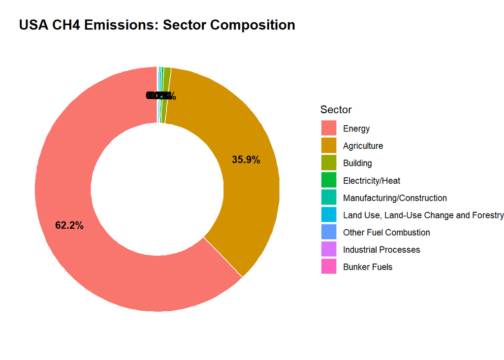

```r
## CLIMATE WATCH CHARTS

library(stringr)

## CLIMATE WATCH CHARTS

# 1) Clean and Aggregate over 1990–2024
cw_total <- cw_ch4 %>%
  filter(year >= 1990, year <= 2024) %>%
  # 1. Strip any accidental spaces from the sector names
  mutate(sector = trimws(as.character(sector))) %>%
  # 2. Drop anything containing "Total" or "Fugitive" safely
  filter(
    !str_detect(sector, regex("Total", ignore_case = TRUE)),
    !str_detect(sector, regex("Fugitive", ignore_case = TRUE))
  ) %>%
  group_by(sector) %>%
  summarise(
    total_emissions = sum(value, na.rm = TRUE),
    .groups = "drop"
  ) %>%
  mutate(
    percentage = total_emissions / sum(total_emissions),
    label = percent(percentage, accuracy = 0.1)
  )

# 2) Plot the Donut Chart
p <- ggplot(cw_total, aes(x = 2, y = percentage, fill = reorder(sector, -percentage))) +
  geom_col(color = "white") +
  coord_polar(theta = "y") +
  xlim(0.5, 2.5) +
  geom_text(aes(label = label),
            position = position_stack(vjust = 0.5),
            size = 3.5, fontface = "bold") +
  theme_void() +
  theme(
    legend.position = "right",
    plot.title = element_text(face = "bold", hjust = 0.5, size = 14)
  ) +
  labs(
    title = "USA CH4 Emissions: Sector Composition",
    fill  = "Sector"
  )

print(p)
```

```r
## FAOSTAT DATA

# 1) Load Libraries -------------------------------------------
library(dplyr)
library(ggplot2)

# 2) Load the Data you saved today ----------------------------
# This uses the specific location you created
file_path <- file.path("data", "group_project", "faostat", "methane_us_1990plus.csv")

if(file.exists(file_path)) {
  methane_us <- read.csv(file_path)
  message("Data loaded successfully!")
} else {
  stop("File not found! Make sure you are in the correct R Project.")
}
```

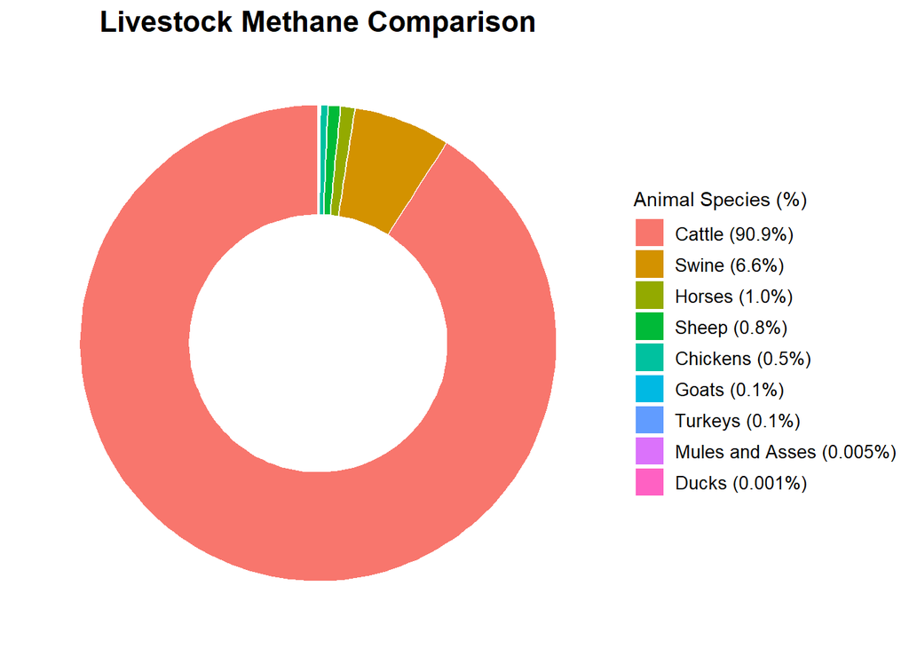

```r
# 1) Define the exact categories
clean_list <- c("Cattle", "Swine", "Horses", "Sheep", "Goats",
                "Chickens", "Turkeys", "Mules and Asses", "Ducks")

# 2) Filter and apply conditional formatting for decimals
donut_data_custom <- methane_us %>%
  filter(Year >= 1990) %>%
  filter(grepl("CH4", Element)) %>%
  filter(Item %in% clean_list) %>%
  group_by(Item) %>%
  summarise(Total_Value = sum(Value, na.rm = TRUE), .groups = 'drop') %>%
  mutate(
    perc_num = (Total_Value / sum(Total_Value)) * 100,
    # Apply 3 decimals ONLY to Mules/Asses and Ducks; 1 decimal for everyone else
    label = ifelse(Item %in% c("Mules and Asses", "Ducks"),
                   paste0(Item, " (", sprintf("%0.3f", perc_num), "%)"),
                   paste0(Item, " (", sprintf("%0.1f", perc_num), "%)"))
  ) %>%
  arrange(desc(Total_Value))

# 3) Create the Donut Chart
ggplot(donut_data_custom, aes(x = 2, y = Total_Value, fill = reorder(label, -Total_Value))) +
  geom_col(color = "white") +
  coord_polar(theta = "y") +
  xlim(0.5, 2.5) +
  theme_void() +
  labs(
    title = "Livestock Methane Comparison",
    fill = "Animal Species (%)"
  ) +
  theme(
    plot.title = element_text(face = "bold", size = 16, hjust = 0.5),
    legend.position = "right",
    legend.text = element_text(size = 10)
  )
```